# wwCon Algorithms Analysis

Eric Bridgeford

January 22, 2017

# wwCon framework

This is not a machine learning algorithm, but rather, a weighted version of traditional measures of timeseries data.

## Weighted Mean

\begin{equation} \mu_c = \frac{\sum_{i=1}^N \pi_{i,c} x_i}{\sum_{i=1}^N \pi_{i,c}} \end{equation}

or our overall mean for a particular condition is just a weighted combination of the means at each timepoint, where our weight vector $w$ just indicates the weight a particular condition is thought to be present at a given time point.

## Weighted Covariance

For the covariance, we use the unbiased sample covariance:

\begin{equation} \Sigma_c = \frac{1}{\sum_{i=1}^N \pi_{i,c} - 1}{\sum_{i=1}^N \pi_{i,c}(x_i - \mu)^T(x_i - \mu)} \end{equation}

## Wilcoxon Signed-Rank Test

Here, the data is clearly paired, as we would expect a relationship between correlation values taken at the within-subject level, and the within-scan level. We do not want to impose parametricity for the covariance values being analyzed, so we proceed with the non-parametric wilcoxon signed-rank test.

## Pseudo Code

### wwCon

Inputs:

1. $ts \in \mathcal{R}^{nt, nroi}$: the timeseries data. 2.$\pi \in \mathcal{R}^{nt, nc}$: the weight vector for each condition.

Outputs:

1. $\Sigma \in \mathcal{R}^{nroi, nroi, nc}$: the covariances for each condition.
2. $\mu \in \mathcal{R}^{nroi, nc}$: the means for each condition.

Algorithm:

1. $\textbf{for}$ $c$ in $1:nc$
- $\Sigma [,,c]$ = $cov(ts, wt=\pi[,c])$ # calculate covariance wrt any nonzero weights
- $\mu [,c]$ = $mean(ts, wt=\pi[,c])$ # calculate mean wrt any nonzero weights
2. $\textbf{endfor}$ # Simulations

```r
  require('MASS')
  source('./wwCon.R')
  source('../drivers/plot_one_mtx.R')

  nt <- 100
  ncond <- 2
  nroi <- 2
  mu <- array(0, dim=c(nroi, ncond))
  mu[,1] <- 3
  mu[,2] <- -3
  sigma <- array(NaN, dim=c(nroi, nroi, ncond))
  sigma[,,1] <- diag(nroi)
  sigma[,,2] <- diag(nroi)
  pi_v <- array(0, dim=c(nt, ncond))
  pi_v[1:50, 1] <- 1
  pi_v[51:100,2] <- 1

  observed_signal <- array(0, dim=c(nt, nroi))
  for (i in 1:ncond) {
    library(randomts)
    observed_signal <- pi_v[,i]*mvrnorm(n = nt, mu = mu[,i], Sigma <- sigma[,,i]) + observed_signal
  }

  test <- wwCon(observed_signal, pi_v)
  trusig <- array(NaN, dim=c(nroi, nroi, ncond))
  trusig[,,1] <- cov(observed_signal[1:50,])
  trusig[,,2] <- cov(observed_signal[51:100,])
  trumean <- array(NaN, dim=c(nroi, ncond))
  trumean[,1] <- mean(observed_signal[1:50,])
  trumean[,2] <- mean(observed_signal[51:100,])
```

## Exploratory

Here, we plot the timeseries as a heat map, followed by an “orthogonal projection” of this heat map, followed by the stimulus onsets.When a condition is 1, it is present; when it is 0, it is not present.

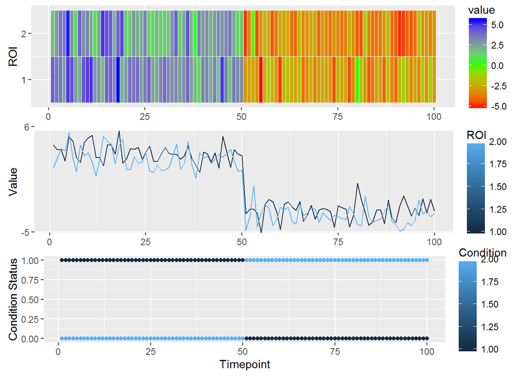

As we can see above, we have two conditions alternating perfectly, and should be able to just about perfectly recover the true means and covariances.

## Results

[figure not shown]

[figure not shown]

## Exploratory

Here, we plot the timeseries as a heat map, followed by an “orthogonal projection” of this heat map, followed by the stimulus onsets.When a condition is 1, it is present; when it is 0, it is not present.

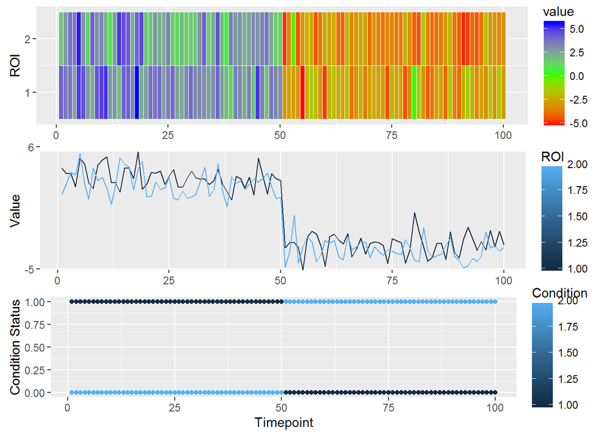

As we can see above, we have two conditions alternating perfectly, and should be able to perfectly recover the true means and covariances.

## Results

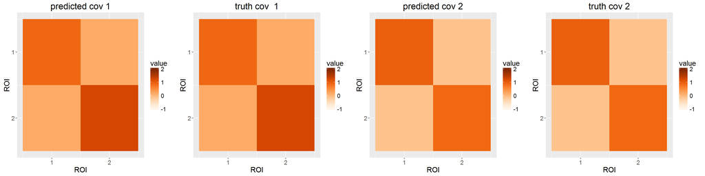

```r
  source('../drivers/plot_one_mtx.R')
sigmalim <- c(ceiling(max(max(trusig), max(test$covs))),
              floor(min(min(trusig), min(test$covs))))
meanlim <- c(ceiling(max(max(trumean), max(test$mean))),
             floor(min(min(trumean), min(test$mean))))
  covplots <- list()
  covplots[[1]] <- plot_one_mtx(test$covs[,,1], lims = sigmalim, title="predicted cov 1", textsize=15)
  covplots[[2]] <- plot_one_mtx(trusig[,,1], lims = sigmalim, title="truth cov  1", textsize=15)
  covplots[[3]] <- plot_one_mtx(test$covs[,,2], lims = sigmalim, title="predicted cov 2", textsize=15)
  covplots[[4]] <- plot_one_mtx(trusig[,,2], lims = sigmalim, title="truth cov 2", textsize=15)

  multiplot(plotlist = covplots, layout=matrix(c(1, 2, 3, 4), nrow=1, byrow=TRUE))
```

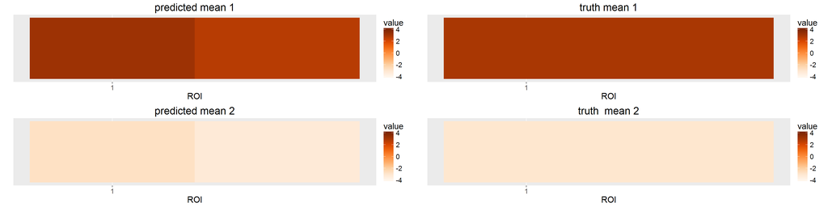

```r
  meanplots <- list()
  meanplots[[1]] <- plot_one_vec(test$means[,1], lims = meanlim, title="predicted mean 1", textsize=15)
  meanplots[[2]] <- plot_one_vec(trumean[,1], lims = meanlim, title="truth mean 1", textsize=15)
  meanplots[[3]] <- plot_one_vec(test$means[,2], lims = meanlim, title="predicted mean 2", textsize=15)
  meanplots[[4]] <- plot_one_vec(trumean[,2], lims = meanlim, title="truth  mean 2", textsize=15)
  multiplot(plotlist = meanplots, layout=matrix(c(1, 2, 3, 4), nrow=2, byrow=TRUE))
```

# Synthetic Data

## Synthetic 1

```r
nt <- 300
nroi <- 3
nsub <- 4
ncond <- 3
covs <- array(NaN, dim=c(nroi, nroi, ncond, nsub))
means <- array(0, dim=c(nroi, ncond, nsub))

subs <- c("s1", "s2", "s1", "s2")
runs <- c("r1", "r1", "r2", "r2")
# generate sources for the random normal distributions
for (x in 1:ncond) {
  for (s in 1:nsub) {
    for (c in 1:ncond) {
      cov_sub <- diag(nroi)
      if (c == 1) {
        cov_sub[1,2] <- .75
        cov_sub[2,1] <- .75
        covs[,,c,s] <- cov_sub
        means[c,c,s] <- 1
      } else if (c == 2) {
        cov_sub[2,3] <- .75
        cov_sub[3,2] <- .75
        covs[,,c,s] <- cov_sub
        means[c,c,s] <- 1
      } else if (c == 3) {
        cov_sub[1,3] <- .75
        cov_sub[3,1] <- .75
        covs[,,c,s] <- cov_sub
        means[c,c,s] <- 1
      }
    }
  }
}
```

```r
get_pi_vector <- function(nt, nc, window, offset=4, overlap=4) {
  conditions <- array(0, dim=c(nt, nc)) # initialize empty condition vector
  for (cond in 1:nc) {
    conditions[seq((cond-1)*overlap + 1, nt, (nc-1)*overlap + offset), cond] <- 1
  }
  source('C:/Users/ebrid/Documents/GitHub/memory/code/R/drivers/convolve_trial_onsets.R')
  return(convolve_conditions(conditions, window))
}

window <- array(c(0, 1, 3, 4, 3, 3, 1, 0))
pi_v <- get_pi_vector(nt, ncond, window)
pi_v[1,] <- array(c(1,0,0))

pi_v <- pi_v/apply(pi_v, MARGIN=1, FUN=sum)
pi_v <- abs(pi_v)

observed_signal <- list()
for (s in 1:(nsub)) {
  signal <- array(0, dim=c(nt, nroi))
  for (c in 1:ncond) {
    signal <- pi_v[,c]*mvrnorm(n = nt, mu = means[,c,s], Sigma <- covs[,,c,s]) + signal
  }
  observed_signal[[s]] <- signal
}
names(observed_signal) <- 1:4
```

## Exploratory Results

### Subject 1

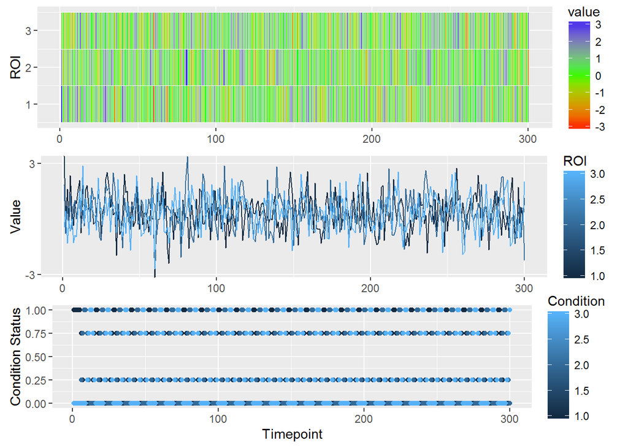

### Subject 2

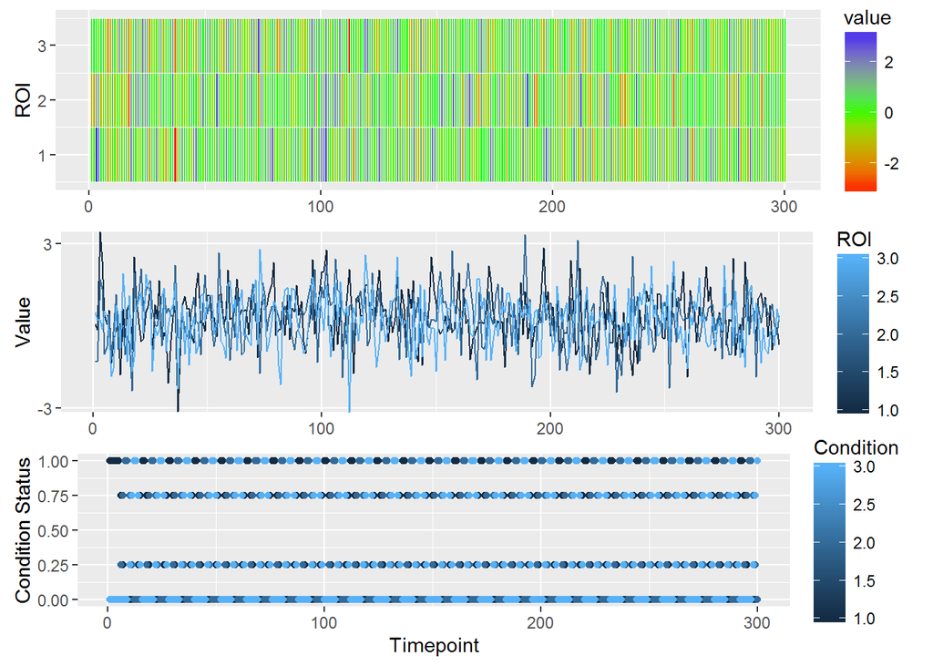

Next, we apply our algorithm to the data:

```r
wwcon_results <- sapply(observed_signal, function(ts) wwCon(ts, pi_vec = pi_v),
                              USE.NAMES=TRUE, simplify=FALSE)
cov_wwcon <- list()
mean_wwcon <- list()

cond_key <- c("c1", "c2", "c3")
for (i in 1:length(cond_key)) {
  cov_wwcon[[cond_key[i]]] <- list()
  mean_wwcon[[cond_key[i]]] <- list()

  for (id in names(wwcon_results)) {
    cov_wwcon[[cond_key[i]]][[id]] <- wwcon_results[[id]]$covs[,,i]
    mean_wwcon[[cond_key[i]]][[id]] <- wwcon_results[[id]]$means[,i]
  }
}
```

### Subject 1 Results

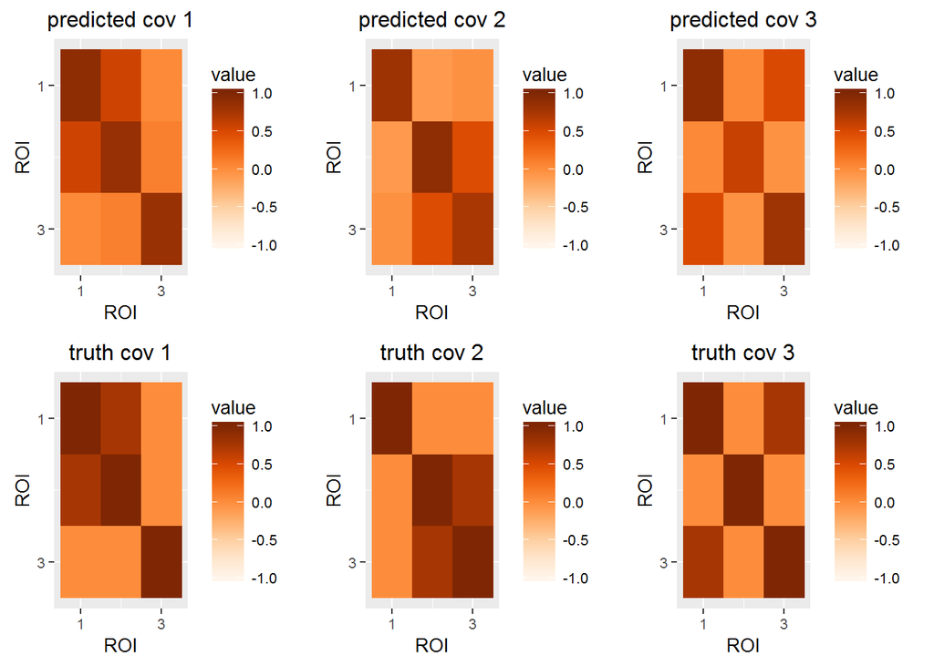

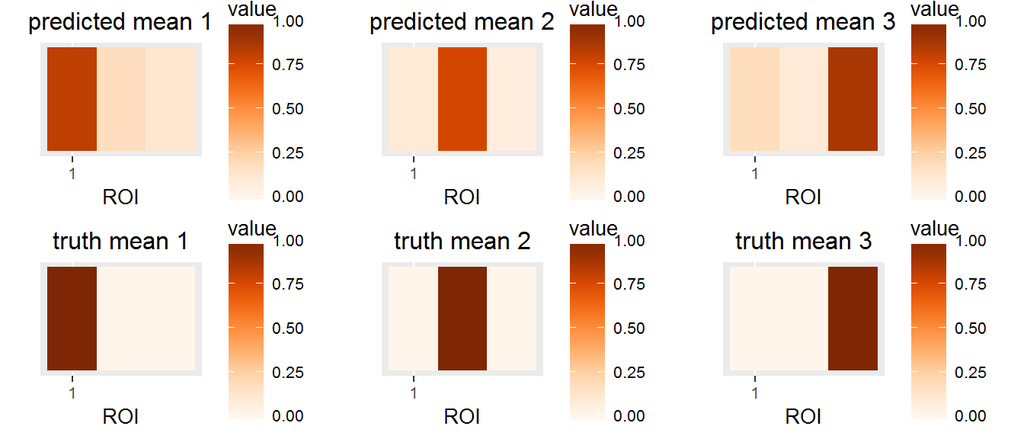

### Subject 2 Results

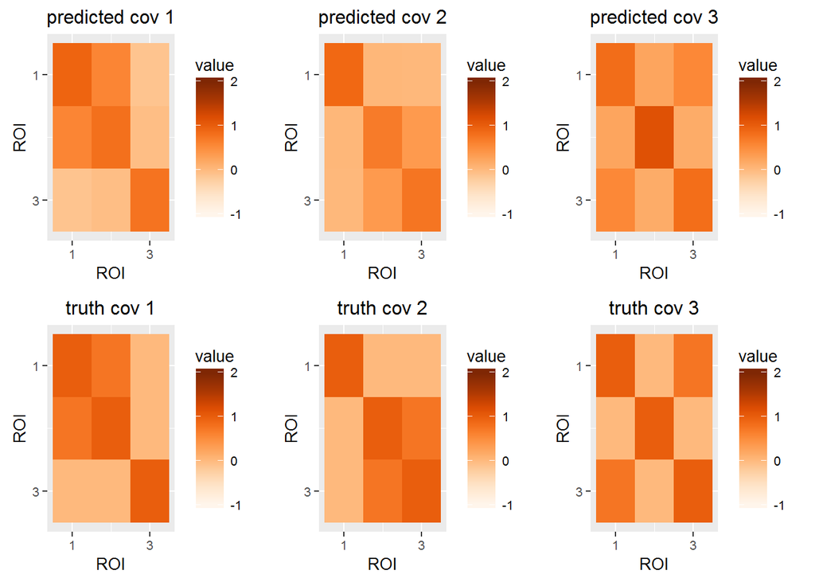

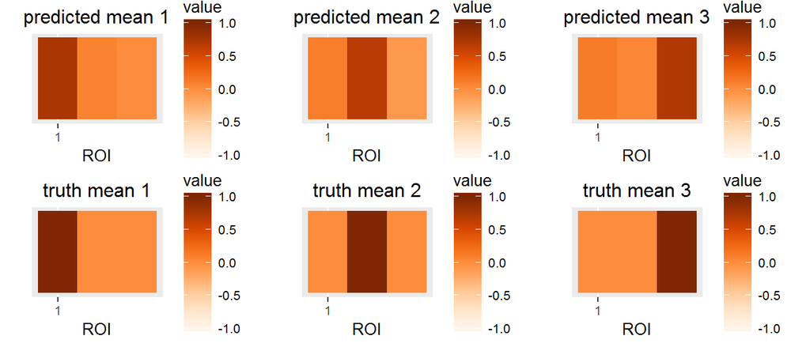

### Subject 3 Results

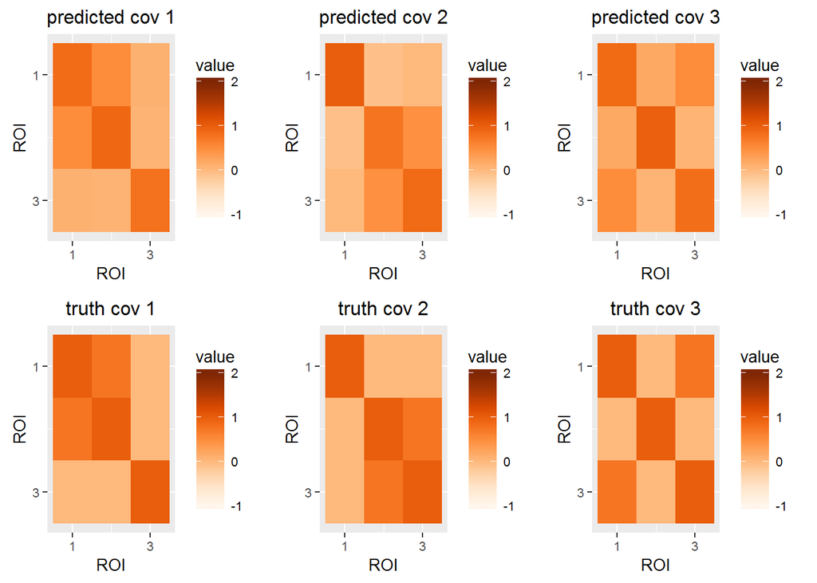

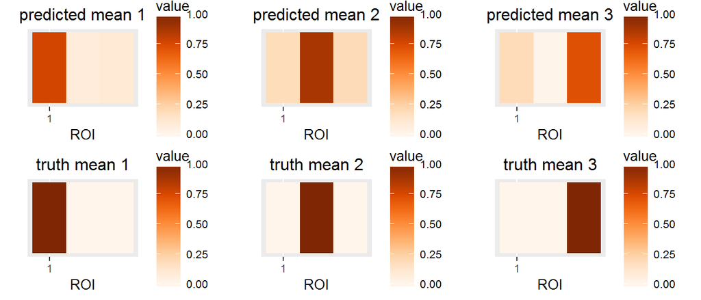

### Subject 4 Results

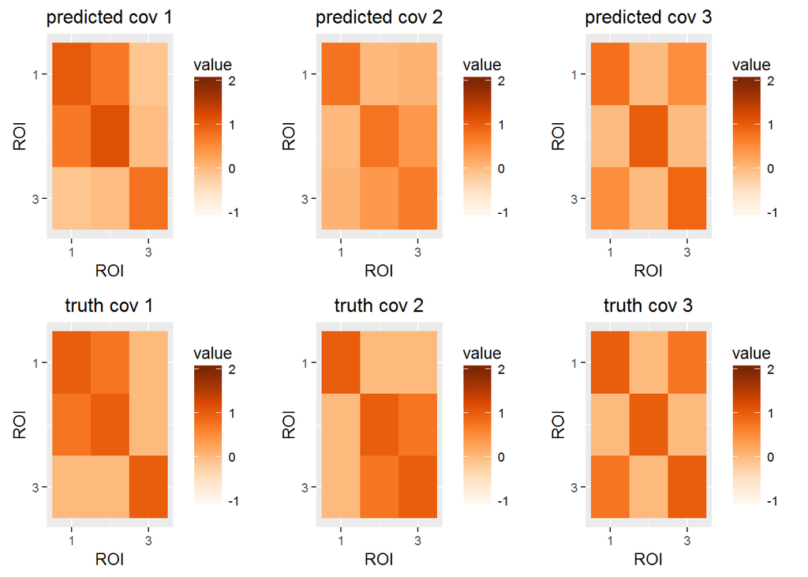

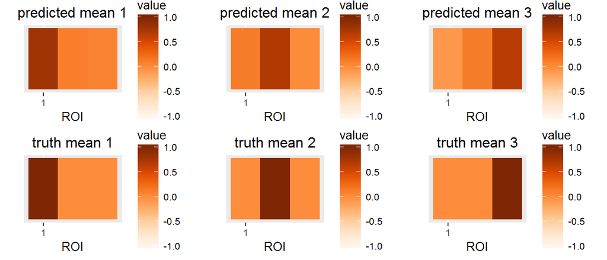

## Wilcoxon Results

### Means

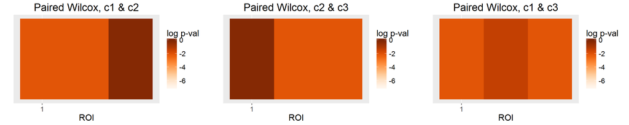

Comparing the means, we can see that, as expected, our wilcoxon test indicates an appreciable difference between ROIs 1 and 2 (since their means are quite different as we replaced ROI 1 for condition 1 and ROI 2 for condition 2). Equivalently the logic follows for condition 2 and condition 3 (we replaced ROI 2 condition 2, ROI 3 condition 3), and for condition 1 and condition 3 (we replaced ROI 1 condition 1, ROI 3 condition 3).

### Covariances

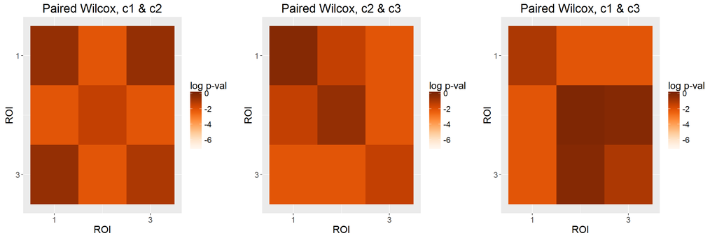

Likewise, we can see that our wilcoxon test indicates appreciable edge differences exactly where expected. Comparing the predicted covariance matrices for conditions 1 and condition 2, it is clear that the most significant edge differences are the (1,2) and (2,3) edges, replaced for condition 1 and condition 2 respectively. We note that the same pattern holds for c2 & c3 as well as c1 & c3.

# Real Data

We get our condition onsets and store our $\pi$ vector:

```r
  ## Condition Onset/Correlation ---------------------------------------------------
  cond_key <- c("Relational", "Locational", "Incorrect")
  onsets <- get_trial_onsets(infopath, ts, subs, runs, onset_cat=c(NaN,1,NaN,2,NaN,1,NaN,2,3), cond_key=cond_key)
  onset_times <- onsets$times
  conditions <- onsets$conditions

  # Asymmetric Window
  fx <- array(rev(c(0, .1, .25, .3, .25, .2, .1, .05)))

  pi_vecs <- sapply(onset_times, function(sub) {
    x <- abs(apply(sub, 2, function(x) as.array(convolve(x, fx, type='open')[1:length(x)])))
    abs(x/apply(x, MARGIN=1, FUN=sum))
  }, USE.NAMES=TRUE, simplify=FALSE)
  # pi_vecs <- sapply(pi_vecs, function(sub) {
  #    sub[,3] <- rep(.1, length=dim(sub)[1])
  #    return(abs(sub))
  # }, USE.NAMES=TRUE, simplify=FALSE)
  # cond_key <- c("Relational", "Locational", "Overall")

  # pi_vecs <- sapply(pi_vecs, function(sub) {
  #    sub[,3] <- rep(.1, length=dim(sub)[1])
  #    return(abs(sub))
  # }, USE.NAMES=TRUE, simplify=FALSE)
  # cond_key <- c("Relational", "Locational", "Overall")
```

```r
  ## Wilcoxon Tests ----------------------------------------------------------

  wwcon_results <- sapply(names(ts), function(sub) wwCon(ts[[sub]], pi_vecs[[sub]]),
                                USE.NAMES=TRUE, simplify=FALSE)
  cov_wwcon <- list()
  mean_wwcon <- list()

  for (i in 1:length(cond_key)) {
    cov_wwcon[[cond_key[i]]] <- list()
    mean_wwcon[[cond_key[i]]] <- list()

    for (id in names(wwcon_results)) {
      cov_wwcon[[cond_key[i]]][[id]] <- wwcon_results[[id]]$covs[,,i]
      mean_wwcon[[cond_key[i]]][[id]] <- wwcon_results[[id]]$means[,i]
    }
  }

  wwcon_mean_wilcox <- wilcox_test_mean(mean_wwcon, subs, runs)

  wwcon_cov_wilcox <- wilcox_test_cov(cov_wwcon, subs, runs)

  wwcon_wilcox_plot_cov <- plot_cov_wilcox(wwcon_cov_wilcox, textsize=15)

  wwcon_wilcox_plot_mean <- plot_mean_wilcox(wwcon_mean_wilcox, atlas, textsize=15)
```

## Results

### Means

#### Relational and Locational

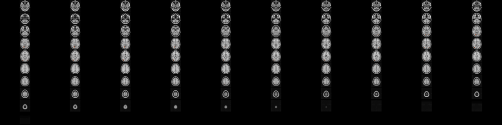

```r
  # atlas is a oro.nifti image
  plot_brain_overlay <- function(atlas, reference, values) {
    require(RColorBrewer)
    ov <- atlas
    # sort the rois so that they go low to small, which is what pipeline outputs
    roimap <- sort(unique(array(atlas@.Data)))
    roimap <- roimap[2:length(roimap)]  # ignore 0 valued roi (no region)
    for (roi in 1:length(values)) {
      if (is.nan(values[roi])) {
        ov@.Data[round(atlas@.Data) == roi] = 0
      } else {
        ov@.Data[round(atlas@.Data) == roi] = 1 - values[roi]
      }
    }
    overlay(reference, ifelse(ov > .95, ov, NA), zlim.y=c(0, 1),
            col.y=brewer.pal(n = 8, name = "Oranges"))
  }

  plot_brain_overlay(atlas, reference, wwcon_mean_wilcox$overall[[1]])
```

#### Relational and Incorrect

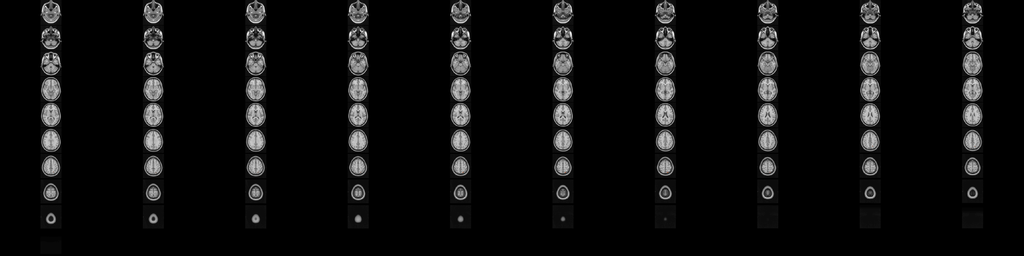

```r
  plot_brain_overlay(atlas, reference, wwcon_mean_wilcox$overall[[2]])
```

#### Locational and Incorrect

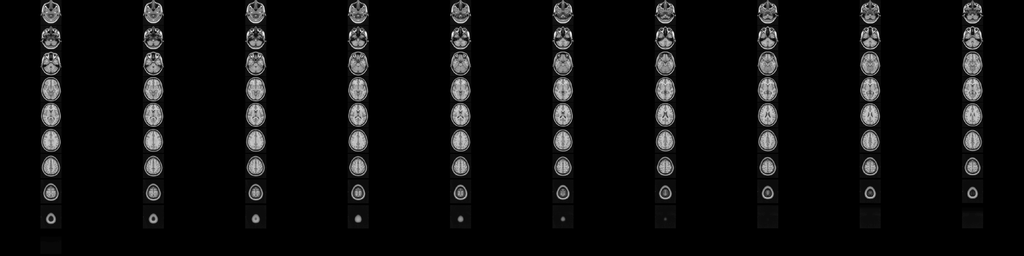

```r
  plot_brain_overlay(atlas, reference, wwcon_mean_wilcox$overall[[3]])
```

### Covariances

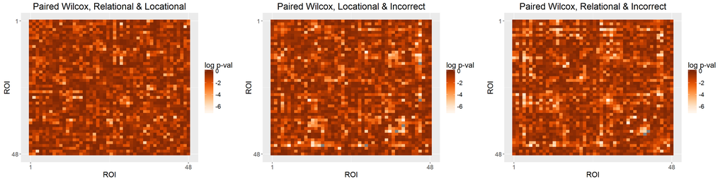

```r
  multiplot(plotlist=list(wwcon_wilcox_plot_cov$overall[[1]], wwcon_wilcox_plot_cov$overall[[3]],
                          wwcon_wilcox_plot_cov$overall[[2]]), layout=matrix(c(1, 2, 3), nrow=1, byrow=TRUE))
```

## Synthetic Data Test 2

Idea: use the means and covariance matrices for the overall timeseries to form a baseline for further investigation. For each condition, in the Relational/Locational wilcoxon results, choose the edges/ROIs with p values less than a threshold. Replace the edges/ROIs for the covariances/means in the relational with the maximum covariance/mean in the entire set, and replace the edges/ROIs for the covariances/means in the locational with the minimum covariance/mean in the entre set.

Here, we would expect the resulting wilcoxon test to show an appreciable difference in the particular edges that we chose to replace.

First, we construct our synthetic matrices for each condition. We begin by constructing an average covariance matrix for each subject; that is, for each subject, we concatenate the timeseries for each run we are considering, and then compute covariance/mean over the timeseries for each subject all at once. From a logical perspective, we are simply assuming that each timeseries per subject is sampled from the same “source” normal distribution, and in our synthetic data, we want to replicate these “sources” as closely as possible.

```r
ts_by_sub <- sapply(unique(subs), function(sub) {
  sub_current <- which(subs == sub) # get the ids of the subjects we want to consider
  ts_sub <- do.call(rbind, ts[sub_current])
}, USE.NAMES=TRUE, simplify=FALSE)
mean_by_sub <- sapply(ts_by_sub, function(ts) {
  apply(ts, MARGIN=2, mean)
}, USE.NAMES=TRUE, simplify=FALSE)
cov_by_sub <- sapply(ts_by_sub, function(ts) {
  cov(ts)
}, USE.NAMES=TRUE, simplify=FALSE)
```

Next, we choose the most significant edges/ROIs based on the bi-conditional wilcoxon results (here, we are most interested in Relational vs Locational activation, so we will use the appropriate wilcoxon results). For each subject’s covariance and mean, we will replace the value of the respective edge/ROI with the max (Relational) and the minimum (Locational) covariance/mean at that particular edge for all subjects in the particular condition.

```r
nt <- 300  # approximately the number of timesteps per subject we will consider
nroi <- 116
niter = 20

pvals <- seq(from=.01, to=.1, by=0.01)  # the probability of an edge being replaced
pvals <- c(pvals, seq(from=0.2, to=1, by=.1))
edges_sorted <- sort(wwcon_cov_wilcox$overall[[1]], index.return=TRUE)$ix # the ids of the sorted indices. Sorted low -> high.
rois_sorted <- sort(wwcon_mean_wilcox$overall[[1]], index.return=TRUE)$ix # the ids of the sorted indices. Sorted low -> high.

roc_cov <- array(NaN, dim=c(length(pvals),niter))
roc_roi <- array(NaN, dim=c(length(pvals),niter))

for (k in 1:niter) {
  for (n in 1:length(pvals)) {
    print(n)
    print(k)
    p <- pvals[n]
    num_edges <- floor(length(edges_sorted)*p)  # number of edges to replace on this iteration
    num_rois <- floor(length(rois_sorted)*p)
    cov_edges <- edges_sorted[1:num_edges]
    mean_rois <- rois_sorted[1:num_rois]

    cov_tuples <- sapply(cov_edges, function(pos) {pos2coord(pos=pos, dim.mat=c(nroi, nroi))})
    rel_loc_mean <- array(NaN, dim=c(2, length(num_rois))) # store the replacement covariance here
    rel_loc_cov <- array(NaN, dim=c(2, dim(cov_tuples)[2])) # store the replacement covariance here

    for (i in 1:dim(cov_tuples)[2]) {
      rel <- wwcon_cov_wilcox$covs$Relational[cov_tuples[,i]]
      loc <- wwcon_cov_wilcox$covs$Locational[cov_tuples[,i]]
      mean_rel <- mean(rel, na.rm=TRUE)
      mean_loc <- mean(loc, na.rm=TRUE)

      # wilcoxon test is symmetric and doesn't give us any insight as to WHICH is greater;
      # just tells us there is a difference. so replace the condition with the greater
      # cov with the overall maximum of that particular condition, and the condition with the lesser
      # cov with the overall minimum of that particular condition. Same for mean.
      if (mean_rel > mean_loc) {
        rel_val <- max(rel, na.rm=TRUE)
        loc_val <- min(loc, na.rm=TRUE)
      } else {
        loc_val <- max(loc, na.rm=TRUE)
        rel_val <- min(rel, na.rm=TRUE)
      }
      rel_loc_cov[,i] <- c(rel_val, loc_val)
    }

    for (j in 1:length(num_rois)) {
      rel <- wwcon_mean_wilcox$means$Relational[mean_rois[j]]
      loc <- wwcon_mean_wilcox$means$Locational[mean_rois[j]]
      mean_rel <- mean(rel, na.rm=TRUE)
      mean_loc <- mean(loc, na.rm=TRUE)

      # wilcoxon test is symmetric and doesn't give us any insight as to WHICH is greater;
      # just tells us there is a difference. so replace the condition with the greater
      # cov with the overall maximum of that particular condition, and the condition with the lesser
      # cov with the overall minimum of that particular condition. Same for mean.
      if (mean_rel > mean_loc) {
        rel_val <- max(rel, na.rm=TRUE)
        loc_val <- min(loc, na.rm=TRUE)
      } else {
        loc_val <- max(loc, na.rm=TRUE)
        rel_val <- min(rel, na.rm=TRUE)
      }

      rel_loc_mean[,j] <- c(rel_val, loc_val)
    }

    sub_cov <- sapply(unique(subs), function(sub) {
      overall <- cov_by_sub[[sub]]
      relational <- overall
      locational <- overall
      for(i in 1:dim(cov_tuples)[2]) {
        relational[cov_tuples[,i]] <- rel_loc_cov[1,i]
        locational[cov_tuples[,i]] <- rel_loc_cov[2,i]
      }

      relational <- (relational + t(relational))/2
      locational <- (locational + t(locational))/2
          return(list(overall=overall, relational=make.positive.definite(relational),
                  locational=make.positive.definite(locational)))
    }, USE.NAMES=TRUE, simplify=FALSE)

    sub_mean <- sapply(unique(subs), function(sub) {
      overall <- mean_by_sub[[sub]]
      relational <- overall
      locational <- overall
      for(i in 1:length(num_rois)) {
        relational[mean_rois[i]] <- rel_loc_mean[1,i]
        locational[mean_rois[i]] <- rel_loc_mean[2,i]
      }
      return(list(overall=overall, relational=relational, locational=locational))
    }, USE.NAMES=TRUE, simplify=FALSE)

    pi_v <- get_pi_vector(nt, ncond, fx, offset=5, overlap=6)
    pi_v[1,] <- array(c(1,0,0))

    pi_v <- abs(pi_v/apply(pi_v, MARGIN=1, FUN=sum))

    conds <- c('overall', 'relational', 'locational')
    ts <- sapply(1:length(subs), function(id) {
      sub <- subs[id]
      signal <- array(0, dim=c(nt, nroi))
      for (c in 1:length(conds)) {
        signal <- pi_v[,c]*mvrnorm(n=nt, mu = array(sub_mean[[sub]][[conds[c]]], dim=c(nroi,1)),
                                   Sigma=sub_cov[[sub]][[conds[c]]]) + signal
      }
      return(signal)
    }, USE.NAMES=TRUE, simplify=FALSE)
    names(ts) <- 1:length(subs)

    wwcon_results <- sapply(names(ts), function(sub) wwCon(ts[[sub]], pi_v),
                                USE.NAMES=TRUE, simplify=FALSE)
    cov_wwcon <- list()
    mean_wwcon <- list()

    for (i in 1:length(cond_key)) {
      cov_wwcon[[cond_key[i]]] <- list()
      mean_wwcon[[cond_key[i]]] <- list()

      for (id in names(wwcon_results)) {
        cov_wwcon[[cond_key[i]]][[id]] <- wwcon_results[[id]]$covs[,,i]
        mean_wwcon[[cond_key[i]]][[id]] <- wwcon_results[[id]]$means[,i]
      }
    }

    wwcon_mean_wilcox <- wilcox_test_mean(mean_wwcon, subs, runs)

    wwcon_cov_wilcox <- wilcox_test_cov(cov_wwcon, subs, runs)

    cmp_edges <- sort(wwcon_cov_wilcox$overall[[1]], index.return=TRUE)$ix[1:num_edges]
    cmp_rois <- sort(wwcon_mean_wilcox$overall[[1]], index.return=TRUE)$ix[1:num_rois]

    edges_correct <- 0
    for (j in cmp_edges) {
      if (j %in% edges_sorted[1:num_edges]) {
        edges_correct <- edges_correct + 1
      }
    }
    rois_correct <- 0
    for (j in cmp_rois) {
      if (j %in% rois_sorted[1:num_rois]) {
        rois_correct <- rois_correct + 1
      }
    }

    roc_cov[n,k] <- edges_correct/num_edges
    roc_roi[n,k] <- rois_correct/num_rois
  }
}
```

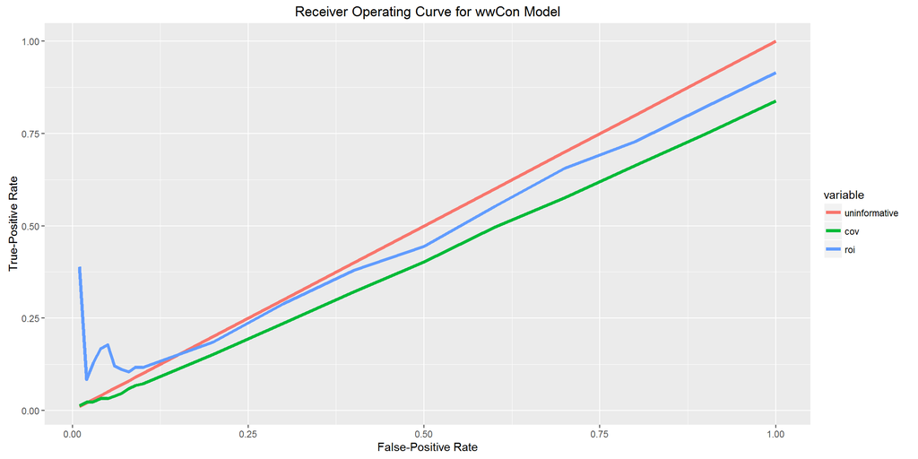

```r
roc_cov <- readRDS(file='./roc_cov_wwcon.RDS')
roc_roi <- readRDS(file='./roc_roi_wwcon.RDS')

roc_cov_avg = apply(roc_cov, MARGIN=c(1), mean, na.rm=TRUE)
roc_roi_avg = apply(roc_roi, MARGIN=c(1), mean, na.rm=TRUE)
roc <- data.frame(pval = pvals, uninformative=pvals, cov=roc_cov_avg, roi=roc_roi_avg)

roc_melted <- melt(roc, id=c('pval'))

ggplot(data = roc_melted, aes(x=pval, y=value, color=variable, group=variable)) +
  geom_line(size=1.5) +
  xlab('False-Positive Rate') +
  ylab('True-Positive Rate') +
  ggtitle('Receiver Operating Curve for wwCon Model')
```